# Valeria.Lopez.Lab1

Valeria López

2026-09-04

#Laboratorio 1

Lectura de los datos

```r
library(readxl)

datos <- read_excel("BaseDatosServidores.xlsx")

head(datos)
```

```
## # A tibble: 6 × 12
##   ID_Nodo  TipoEntorno ProveedorCloud NivelCarga EstadoServidor UsoCPU
##   <chr>    <chr>       <chr>          <chr>      <chr>           <dbl>
## 1 NODE-001 BD          AWS            Bajo       Óptimo           25.3
## 2 NODE-002 BD          GCP            Alto       Crítico          89
## 3 NODE-003 WebAPI      Azure          Medio      Degradado        66.9
## 4 NODE-004 WebAPI      AWS            Bajo       Óptimo           31
## 5 NODE-005 BD          AWS            Medio      Óptimo           61.9
## 6 NODE-006 WebAPI      AWS            Alto       Crítico          98.7
## # ℹ 6 more variables: ContenedoresActivos <dbl>, UsoRAM <dbl>,
## #   AnchoBanda <dbl>, Latencia <dbl>, TasaErrores <dbl>, TiempoUpTime <dbl>
```

```r
str(datos)
```

```
## tibble [100 × 12] (S3: tbl_df/tbl/data.frame)
##  $ ID_Nodo            : chr [1:100] "NODE-001" "NODE-002" "NODE-003" "NODE-004" ...
##  $ TipoEntorno        : chr [1:100] "BD" "BD" "WebAPI" "WebAPI" ...
##  $ ProveedorCloud     : chr [1:100] "AWS" "GCP" "Azure" "AWS" ...
##  $ NivelCarga         : chr [1:100] "Bajo" "Alto" "Medio" "Bajo" ...
##  $ EstadoServidor     : chr [1:100] "Óptimo" "Crítico" "Degradado" "Óptimo" ...
##  $ UsoCPU             : num [1:100] 25.3 89 66.9 31 61.9 98.7 46.5 17.6 24.9 89.1 ...
##  $ ContenedoresActivos: num [1:100] 3 5 12 8 4 11 10 18 9 3 ...
##  $ UsoRAM             : num [1:100] 51.3 42 21.3 23.8 43.1 23.8 26.6 15.1 27.5 41 ...
##  $ AnchoBanda         : num [1:100] 309 219 748 777 186 ...
##  $ Latencia           : num [1:100] 10.3 95 88.9 14.6 46.5 ...
##  $ TasaErrores        : num [1:100] 1.43 1.99 0.52 0.51 0.45 0.74 1.05 0.5 1.14 0.97 ...
##  $ TiempoUpTime       : num [1:100] 357 62 241 199 307 194 128 259 348 305 ...
```

Pregunta 1: Utilice la información de la base de datos para construir un cuadro de distribución de frecuencias que resuma la información correspondiente a la variable Estado del Servidor, tome en cuenta que el cuadro deberá incluir solamente tres columnas: variable (clase), frecuencias absolutas simples y porcentajes. Incluya TODOS los elementos o componentes de presentación vistos en clase que debe tener cualquier representación de información para facilitar la lectura.

```r
# Frecuencias absolutas
frecuencias <- table(datos$EstadoServidor)

# Porcentajes
porcentajes <- prop.table(frecuencias) * 100

# Construcción de la tabla
tabla_estado <- data.frame(
  Variable = names(frecuencias),
  Frecuencia = as.vector(frecuencias),
  Porcentaje = round(as.vector(porcentajes), 2)
)

# Agregar total
tabla_estado <- rbind(
  tabla_estado,
  data.frame(
    Variable = "Total",
    Frecuencia = sum(tabla_estado$Frecuencia),
    Porcentaje = sum(tabla_estado$Porcentaje)
  )
)

tabla_estado
```

```
##    Variable Frecuencia Porcentaje
## 1   Crítico         19         19
## 2 Degradado         29         29
## 3    Óptimo         52         52
## 4     Total        100        100
```

Pregunta 2: Construya un gráfico que represente la información de la variable Nivel de Carga según Tipo de Entorno. Debe cuidar que la presentación del gráfico sea adecuada, pero no debe incluir TODOS los elementos o componentes de presentación vistos en clase que debe tener cualquier gráfico.

```r
# Tabla de contingencia
tabla_carga <- table(datos$TipoEntorno, datos$NivelCarga)

tabla_carga
```

```
##
##          Alto Bajo Medio
##   Batch     6    4     8
##   BD       10    5    14
##   WebAPI   17   15    21
```

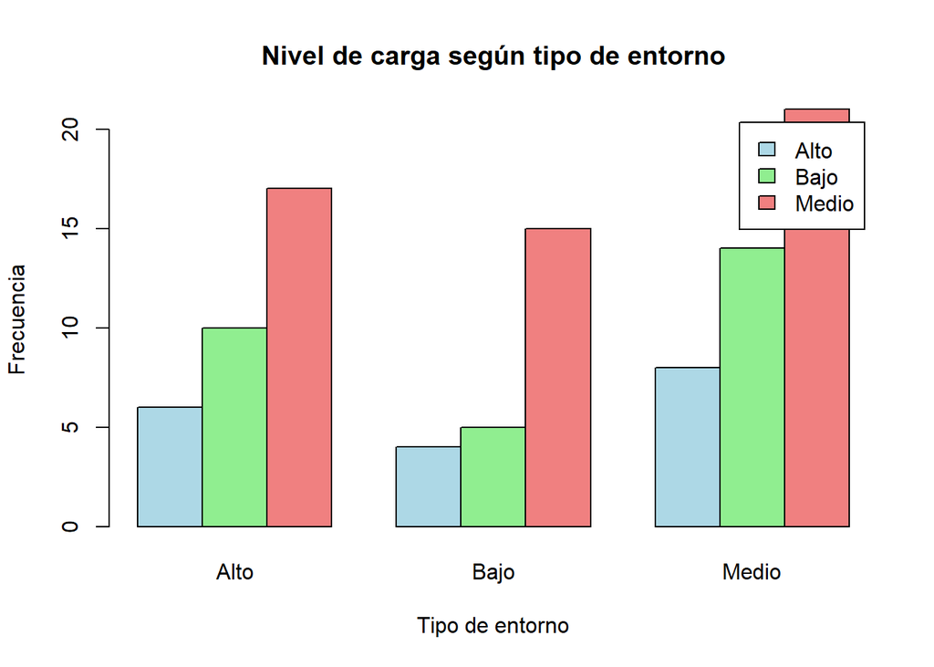

```r
# Gráfico
barplot(
  tabla_carga,
  beside = TRUE,
  main = "Nivel de carga según tipo de entorno",
  xlab = "Tipo de entorno",
  ylab = "Frecuencia",
  col = c("lightblue", "lightgreen", "lightcoral"),
  legend.text = colnames(tabla_carga)
)
```

Pregunta 3: Construya un Polígono de frecuencias absolutas para representar la Variable Uso de CPU, el ancho de las clases debe ser de 10, no debe tener elementos de presentación, pero sí debe ser legible el gráfico y cumplir con las características de un polígono de frecuencias absolutas.

```r
# Determinar límites de clases con amplitud 10
limite_inferior <- floor(min(datos$UsoCPU, na.rm = TRUE) / 10) * 10
limite_superior <- ceiling(max(datos$UsoCPU, na.rm = TRUE) / 10) * 10

# Crear intervalos
intervalos <- seq(limite_inferior, limite_superior, by = 10)

# Clasificar los datos
clases_cpu <- cut(
  datos$UsoCPU,
  breaks = intervalos,
  right = FALSE,
  include.lowest = TRUE
)

# Frecuencias absolutas
frecuencias_cpu <- table(clases_cpu)

frecuencias_cpu
```

```
## clases_cpu
##  [10,20)  [20,30)  [30,40)  [40,50)  [50,60)  [60,70)  [70,80)  [80,90)
##        7       13        4       13       14       15       10       10
## [90,100]
##       14
```

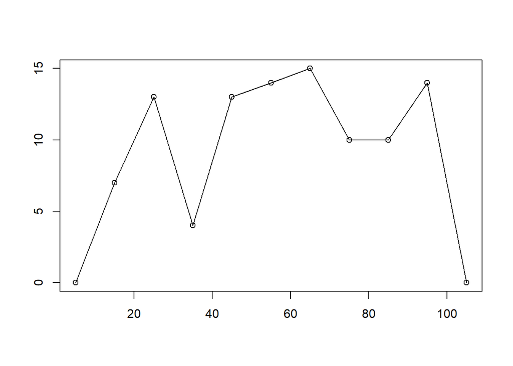

```r
# Marcas de clase
marcas <- head(intervalos, -1) + 5

# Cerrar el polígono
marcas_poligono <- c(marcas[1] - 10, marcas, marcas[length(marcas)] + 10)
frecuencias_poligono <- c(0, as.vector(frecuencias_cpu), 0)

# Crea Polígono de frecuencias
plot(
  marcas_poligono,
  frecuencias_poligono,
  type = "o",
  xlab = "",
  ylab = ""
)
```

Pregunta 4: Calcule la Mediana y desviación estándar para la variable Latencia para Tipo de Entorno: WebAPI.

```r
# Filtrar servidores WebAPI
webapi <- subset(datos, TipoEntorno == "WebAPI")

# Calcular mediana
mediana_latencia <- median(webapi$Latencia, na.rm = TRUE)

# Calcular desviación estándar
desviacion_latencia <- sd(webapi$Latencia, na.rm = TRUE)

# Mostrar resultados
mediana_latencia
```

```
## [1] 35.6
```

```r
desviacion_latencia
```

```
## [1] 40.0263
```

Pregunta 5: Calcule el cuartil 1 y el decil 7 para la variable Uso de RAM.

```r
# Primer cuartil
Q1 <- quantile(datos$UsoRAM, probs = 0.25, na.rm = TRUE)

# Séptimo decil
D7 <- quantile(datos$UsoRAM, probs = 0.70, na.rm = TRUE)

# Mostrar resultados
Q1
```

```
##   25%
## 18.95
```

```r
D7
```

```
##  70%
## 34.3
```

El **primer cuartil (Q1)** indica el valor de uso de RAM por debajo del cual se encuentra aproximadamente el 25% de los servidores.

El **séptimo decil (D7)** indica el valor de uso de RAM por debajo del cual se encuentra aproximadamente el 70% de los servidores.

Pregunta 6: Construya un diagrama de cajas para la variable Tasa de Errores según Estado del Servidor. Debe cuidar que la presentación del gráfico sea adecuada, pero no debe incluir TODOS los elementos o componentes de presentación vistos en clase que debe tener cualquier gráfico.

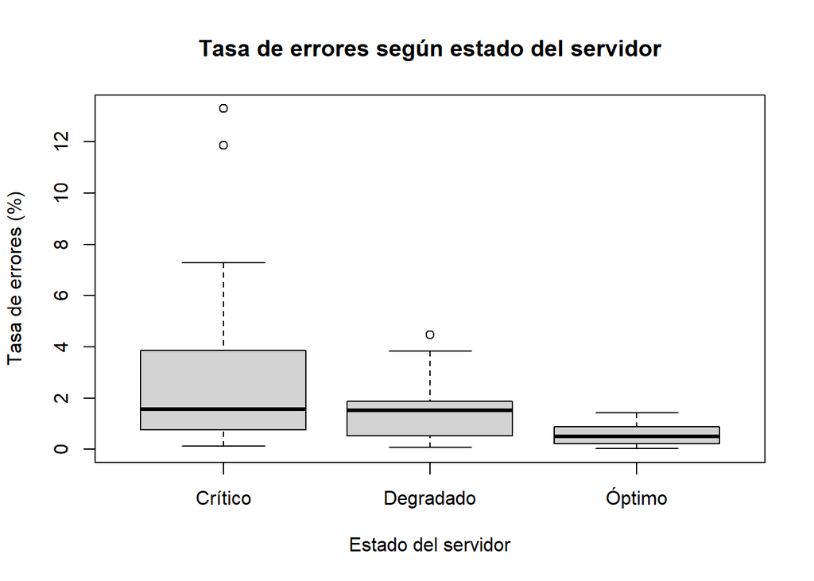

```r
boxplot(
  TasaErrores ~ EstadoServidor,
  data = datos,
  main = "Tasa de errores según estado del servidor",
  xlab = "Estado del servidor",
  ylab = "Tasa de errores (%)"
)
```

Pregunta 7: Determine cuál de las dos variables tiene mayor variabilidad relativa, el Número de Contenedores Activos para los que tienen Proveedor Cloud: AWS o Número de Contenedores Activos para los que tienen Proveedor Cloud: Azure.

```r
# Datos de AWS
aws <- subset(datos, ProveedorCloud == "AWS")

# Datos de Azure
azure <- subset(datos, ProveedorCloud == "Azure")

# Estadísticos AWS
media_aws <- mean(aws$ContenedoresActivos, na.rm = TRUE)
sd_aws <- sd(aws$ContenedoresActivos, na.rm = TRUE)
cv_aws <- (sd_aws / media_aws) * 100

# Estadísticos Azure
media_azure <- mean(azure$ContenedoresActivos, na.rm = TRUE)
sd_azure <- sd(azure$ContenedoresActivos, na.rm = TRUE)
cv_azure <- (sd_azure / media_azure) * 100

# Tabla de resultados
tabla_cv <- data.frame(
  Proveedor = c("AWS", "Azure"),
  Media = c(media_aws, media_azure),
  DesviacionEstandar = c(sd_aws, sd_azure),
  CoeficienteVariacion = c(cv_aws, cv_azure)
)

tabla_cv
```

```
##   Proveedor     Media DesviacionEstandar CoeficienteVariacion
## 1       AWS 11.204082           6.314598             56.35980
## 2     Azure  9.741935           6.617994             67.93305
```

```r
if (cv_aws > cv_azure) {
  cat("AWS presenta mayor variabilidad relativa.\n")
} else {
  cat("Azure presenta mayor variabilidad relativa.\n")
}
```

```
## Azure presenta mayor variabilidad relativa.
```